# Challenge B

Greta FAVARO Garance MASBOU TD1

Github repository : https://github.com/Greta33/Challenge-B

[Be careful : for the Task3B, step 1, you have to write your own path to the CNIL data frame before running the knit.]

## TASK 1B

First we import the data frame and call it “train”.

#### Step 1

We choose the random forest method. Random forest will allow us to find the links between the target variables and the explanatory variables. It is a machine learning algoritsm. Random Forest will classify the explanatory variables according to their links with the variable to be explained.

#### Step 2

After installing the package “randomForest” and remove the column “ID”, we can training the data.

```r
set.seed(123)
model_MLE <- randomForest(SalePrice ~., data=train2,na.action = na.roughfix)
model_MLE_prediction_train <- predict (model_MLE, data=train2)
```

#### Step 3

Now, we can compare the predictions of the random forest model with the ones of an OLS model on the “test” data.

The MLE model :

```r
model_MLE_prediction_test <- predict (model_MLE, data=test2)
head(model_MLE_prediction_test)
```

```
##        1        2        3        4        5        6
## 205725.2 178793.2 215149.5 192257.0 298027.5 151722.1
```

The OLS model :

```r
model_OLS <- lm(SalePrice ~ MSZoning + LotArea + Neighborhood  + YearBuilt + OverallQual, data = train2)
model_OLS_prediction_test <- predict(model_OLS, data=test2)
head(model_OLS_prediction_test)
```

```
##        1        2        3        4        5        6
## 211086.9 205931.6 213830.6 223423.0 339264.4 146217.0
```

## Task 2B

#### Step 1

```r
ll.fit.lowflex <- npreg(y ~ x, data = training, method = "ll", bws = 0.5)
summary(ll.fit.lowflex)
```

```
##
## Regression Data: 122 training points, in 1 variable(s)
##                 x
## Bandwidth(s): 0.5
##
## Kernel Regression Estimator: Local-Constant
## Bandwidth Type: Fixed
## Residual standard error: 1.442574
## R-squared: 0.8569977
##
## Continuous Kernel Type: Second-Order Gaussian
## No. Continuous Explanatory Vars.: 1
```

#### Step 2

```r
ll.fit.highflex <- npreg(y ~ x, data = training, method = "ll", bws = 0.01)
summary(ll.fit.highflex)
```

```
##
## Regression Data: 122 training points, in 1 variable(s)
##                  x
## Bandwidth(s): 0.01
##
## Kernel Regression Estimator: Local-Constant
## Bandwidth Type: Fixed
## Residual standard error: 0.5882872
## R-squared: 0.9569811
##
## Continuous Kernel Type: Second-Order Gaussian
## No. Continuous Explanatory Vars.: 1
```

#### Step 3

We plot the prediction of these two models.

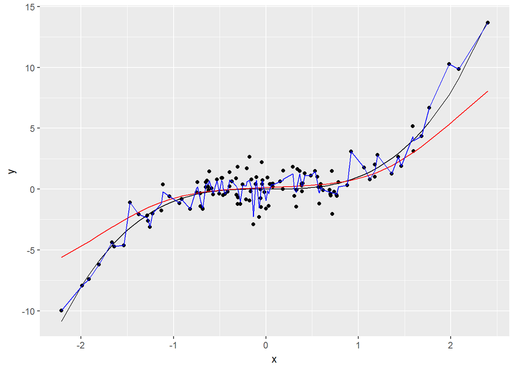

```r
df <- df %>% mutate(y.ll.lowflex = predict(object = ll.fit.lowflex, newdata = df), y.ll.highflex = predict(object = ll.fit.highflex, newdata = df))
training <- training %>% mutate(y.ll.lowflex = predict(object = ll.fit.lowflex, newdata = training), y.ll.highflex = predict(object = ll.fit.highflex, newdata = training))

ggplot(training) + geom_point(mapping = aes(x = x, y = y)) +
  geom_line(mapping = aes(x = x, y = y.true)) +
  geom_line(mapping = aes(x = x, y = y.ll.lowflex), color = "red") +
  geom_line(mapping = aes(x = x, y = y.ll.highflex), color = "blue")
```

#### Step 4

The high-flexibility local linear model (blue line) has more variable predictions compared to the low-flexibility local linear model (red line). So we think that the bias of the high-flexibility local linear model should be lower that the one of the low-flexibility local linear model.

#### Step 5

Now we do the same on the test data:

```r
ll.fit.lowflex2 <- npreg(y ~ x, data = test, method = "ll", bws = 0.5)
summary(ll.fit.lowflex2)
```

```
##
## Regression Data: 28 training points, in 1 variable(s)
##                 x
## Bandwidth(s): 0.5
##
## Kernel Regression Estimator: Local-Constant
## Bandwidth Type: Fixed
## Residual standard error: 1.351958
## R-squared: 0.8439007
##
## Continuous Kernel Type: Second-Order Gaussian
## No. Continuous Explanatory Vars.: 1
```

```r
ll.fit.highflex2 <- npreg(y ~ x, data = test, method = "ll", bws = 0.01)
summary(ll.fit.highflex2)
```

```
##
## Regression Data: 28 training points, in 1 variable(s)
##                  x
## Bandwidth(s): 0.01
##
## Kernel Regression Estimator: Local-Constant
## Bandwidth Type: Fixed
## Residual standard error: 0.1660755
## R-squared: 0.9955011
##
## Continuous Kernel Type: Second-Order Gaussian
## No. Continuous Explanatory Vars.: 1
```

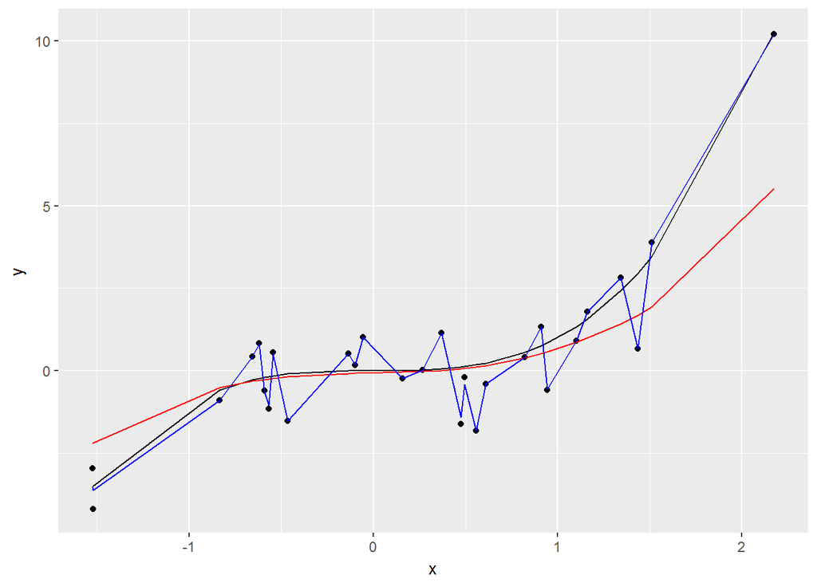

```r
df <- df %>% mutate(y.ll.lowflex2 = predict(object = ll.fit.lowflex2, newdata = df), y.ll.highflex2 = predict(object = ll.fit.highflex2, newdata = df))
test <- test %>% mutate(y.ll.lowflex2 = predict(object = ll.fit.lowflex2, newdata = test), y.ll.highflex2 = predict(object = ll.fit.highflex2, newdata = test))

ggplot(test) + geom_point(mapping = aes(x = x, y = y)) +
  geom_line(mapping = aes(x = x, y = y.true)) +
  geom_line(mapping = aes(x = x, y = y.ll.lowflex2), color = "red") +
  geom_line(mapping = aes(x = x, y = y.ll.highflex2), color = "blue")
```

We find the same effect that in the previous question about the predictions and the bias.

#### Step 6

We create vector of several bandwidth.

```r
bw <- seq(0.01, 0.5, by = 0.001)
```

#### Step 7

We train local linear model y ~ x on training with each bandwidth.

```r
llbw.fit <- lapply(X = bw, FUN = function(bw) {npreg(y ~ x, data = training, method = "ll", bws = bw)})
```

#### Step 8

We compute for each bandwidth the MSE-training.

```r
mse.training <- function(fit.model){
  predictions <- predict(object = fit.model, newdata = training)
  training %>% mutate(squared.error = (y - predictions)^2) %>% summarize(mse = mean(squared.error))
}
mse.train.results <- unlist(lapply(X = llbw.fit, FUN = mse.training))
```

#### Step 9

We compute for each bandwidth the MSE-test.

```r
mse.test <- function(fit.model){
  predictions <- predict(object = fit.model, newdata = test)
  test %>% mutate(squared.error = (y - predictions)^2) %>% summarize(mse = mean(squared.error))
}
mse.test.results <- unlist(lapply(X = llbw.fit, FUN = mse.test))
```

#### Step 10

We plot the MSE-training and the MSE-test.

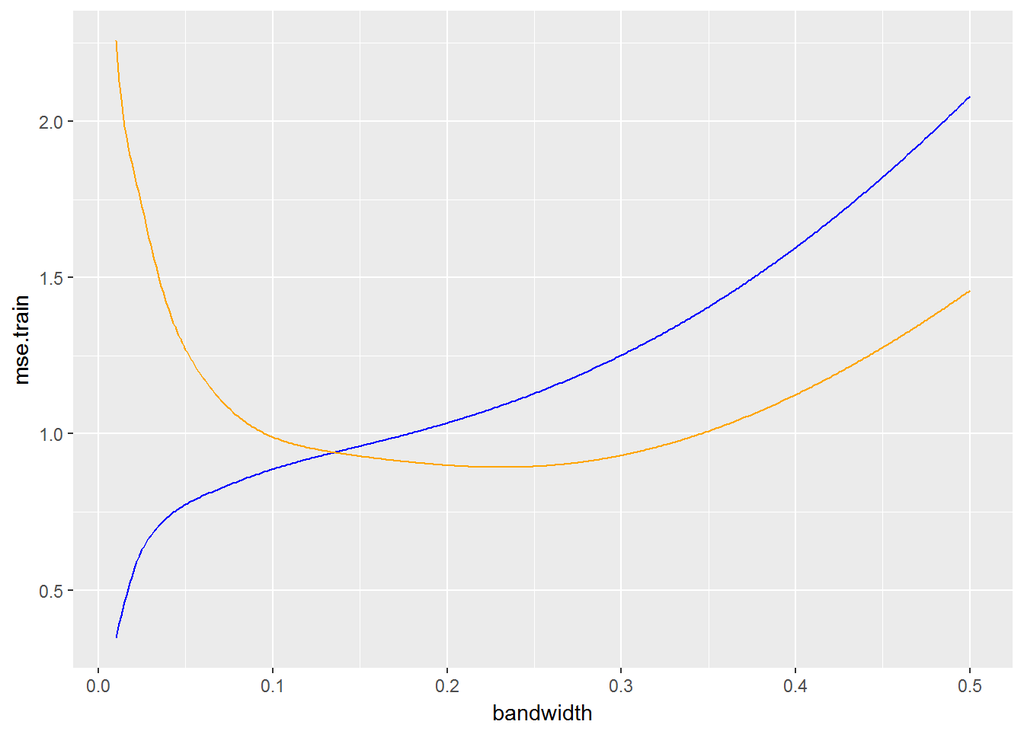

```r
mse.df <- tbl_df(data.frame(bandwidth = bw, mse.train = mse.train.results, mse.test = mse.test.results))

ggplot(mse.df) +
  geom_line(mapping = aes(x = bandwidth, y = mse.train), color = "blue") +
  geom_line(mapping = aes(x = bandwidth, y = mse.test), color = "orange")
```

## TASK 3B

#### Step 1

We just import the data frame and call it “cnil”.

#### Step 2

First, we have to clean the data frame “cnil”.

```r
remove.na <- cnil %>% summarise_all(.funs = funs(sum(is.na(.)))) %>% gather(key = "feature", value = "missing.observations") %>% filter(missing.observations > 100) %>% select(feature) %>% unlist
cnil <- cnil %>% select(- one_of(remove.na))
cnil <- cnil %>% filter(is.na(Adresse) == FALSE, is.na(`Code Postal`) == FALSE, is.na(Ville) == FALSE)
cnil <- data.frame(cnil)
```

Now, we just cut the variables.

```r
dept <- str_sub(`Code Postal`, start=1, end=2)
dept <- as.numeric(dept)
cnil2 <- data.frame(Responsable,dept)
```

Finally, we can create our final data frame.

```r
Final_table <- table(dept)
Final_table <- data.frame(Final_table)
colnames(Final_table) <- c("Department", "Organizations")
head(Final_table)
```

```
##   Department Organizations
## 1         10           121
## 2         11           117
## 3         12           110
## 4         13           488
## 5         14           273
## 6         15            60
```